# Conditional Processing and Plotting

MA505

## Agenda

1. Recall: `FORMAT`, `PROC SORT`, and the DATA step
2. Conditional processing with `IF`/`THEN`/`ELSE`
3. Running more than one statement with `DO` and `END`
4. Plotting frequencies with `PROC FREQ`
5. Plotting with `PROC SGPLOT`

## Recall

| **`FORMAT`** | tells SAS how to display numeric, character, date, or datetime values when we print or output our data |
| --- | --- |
| **`PROC SORT`** | sorts our data, and is a way to remove duplicates from our data |
| **DATA step** | creates new SAS tables, filters rows, computes new columns, and uses SAS functions |

## Conditional processing

**DATA** *output-table*;  
**SET** *input-table*;  
**IF** *expression* **THEN** *statement*;  
<**ELSE IF** *expression* **THEN** *statement*;>  
<**ELSE** *statement*;>  
**RUN;**

- `IF` checks each row. If the expression is true, SAS runs the statement after `THEN`.
- `ELSE IF` and `ELSE` are optional. SAS stops at the first one that is true.

## `IF`/`THEN`: example

Let’s label each car as `Okay` or `Too High` based on its price.

```sas
/* if-then in a data step */
data cars_new;
    set sashelp.cars;
    if MSRP < 30000 then Cost = "Okay";
    if MSRP >= 30000 then Cost = "Too High";
    keep Make Model Type MSRP Cost;
run;

proc print data=cars_new (obs=10);
run;
```

The Print Procedure

| Obs | Make | Model | Type | MSRP | Cost |
| --- | --- | --- | --- | --- | --- |
| 1 | Acura | MDX | SUV | $36,945 | Too |
| 2 | Acura | RSX Type S 2dr | Sedan | $23,820 | Okay |
| 3 | Acura | TSX 4dr | Sedan | $26,990 | Okay |
| 4 | Acura | TL 4dr | Sedan | $33,195 | Too |
| 5 | Acura | 3.5 RL 4dr | Sedan | $43,755 | Too |
| 6 | Acura | 3.5 RL w/Navigation 4dr | Sedan | $46,100 | Too |
| 7 | Acura | NSX coupe 2dr manual S | Sports | $89,765 | Too |
| 8 | Audi | A4 1.8T 4dr | Sedan | $25,940 | Okay |
| 9 | Audi | A41.8T convertible 2dr | Sedan | $35,940 | Too |
| 10 | Audi | A4 3.0 4dr | Sedan | $31,840 | Too |

## `IF`/`THEN`: setting the length

We fix this with a `LENGTH` statement **before** the column is used. `$` means character, and `10` is the number of characters.

```sas
/* if-then in a data step */
data cars_new;
    set sashelp.cars;
    length Cost $ 10;
    if MSRP < 30000 then Cost = "Okay";
    else Cost = "Too High";
    keep Make Model Type MSRP Cost;
run;

proc print data=cars_new (obs=10);
run;
```

The Print Procedure

| Obs | Make | Model | Type | MSRP | Cost |
| --- | --- | --- | --- | --- | --- |
| 1 | Acura | MDX | SUV | $36,945 | Too High |
| 2 | Acura | RSX Type S 2dr | Sedan | $23,820 | Okay |
| 3 | Acura | TSX 4dr | Sedan | $26,990 | Okay |
| 4 | Acura | TL 4dr | Sedan | $33,195 | Too High |
| 5 | Acura | 3.5 RL 4dr | Sedan | $43,755 | Too High |
| 6 | Acura | 3.5 RL w/Navigation 4dr | Sedan | $46,100 | Too High |
| 7 | Acura | NSX coupe 2dr manual S | Sports | $89,765 | Too High |
| 8 | Audi | A4 1.8T 4dr | Sedan | $25,940 | Okay |
| 9 | Audi | A41.8T convertible 2dr | Sedan | $35,940 | Too High |
| 10 | Audi | A4 3.0 4dr | Sedan | $31,840 | Too High |

We also changed the second `IF` to `ELSE`. Every car that is not under 30,000 must be 30,000 or more, so we don’t need to check again.

## More than one statement: `DO` and `END`

**DATA** *output-table*;  
**SET** *input-table*;  
**IF** *expression* **THEN DO**;  
<*multiple statements*>  
**END**;  
<**ELSE IF** *expression* **THEN DO**;  
<*multiple statements*>  
**END**;>  
<**ELSE DO**;  
<*multiple statements*>  
**END**;>  
**RUN;**

`THEN` only runs **one** statement. To run more than one, wrap them in `DO;` … `END;`.

## `DO` and `END`: example

We can also write rows to **different tables**. List all the tables on the `DATA` statement, then use `OUTPUT` to say where each row goes.

```sas
/* if-then extension */
data under40 over40;
    set sashelp.cars;
    keep Make Model MSRP Cost;
    if MSRP < 20000 then do;
        Cost = 1;
        output under40;
    end;
    else if MSRP < 40000 then do;
        Cost = 2;
        output under40;
    end;
    else do;
        Cost = 3;
        output over40;
    end;
run;
```

Check the log to see how many rows went to each table. You can also open **WORK.UNDER40** and **WORK.OVER40** in the Libraries pane.

## Exercise

Use the Overwatch stats table `ma505.ow_stats` (not the heroes table).

1. Create a new column `HighestVal` with the highest value of `Damage`, `Heals`, and `Mitigation`. Create another column `Category` that says which one it was.

   | Damage | Heals | Mitigation | HighestVal | Category |
   | --- | --- | --- | --- | --- |
   | 10432 | 2345 | 985 | 10432 | DAMAGE |

2. Change the code so that rows where `Category` is DAMAGE go to a new table called `damage`, HEALS to a table called `heals`, and MITIGATION to a table called `mitigation`.
   1. How many observations are in each new table?

Save the full table with `Category` as `ma505.ow_cat`. We will use it in the next exercise.

```sas
libname ma505 "~";    /* skip if your autoexec does this */

data ma505.ow_cat damage heals mitigation;
    set ma505.ow_stats;
    length Category $ 10;
    HighestVal = max(Damage, Heals, Mitigation);
    if HighestVal = Damage then do;
        Category = "DAMAGE";
        output damage;
    end;
    else if HighestVal = Heals then do;
        Category = "HEALS";
        output heals;
    end;
    else do;
        Category = "MITIGATION";
        output mitigation;
    end;
    output ma505.ow_cat;    /* every row also goes to the full table */
run;

/* how many rows in each category? */
proc freq data=ma505.ow_cat;
    tables Category;
run;
```

The FREQ Procedure

| Category | Frequency | Percent | Cumulative Frequency | Cumulative Percent |
| --- | --- | --- | --- | --- |
| DAMAGE | 54 | 62.07 | 54 | 62.07 |
| HEALS | 33 | 37.93 | 87 | 100.00 |

**DAMAGE** has 54 observations and **HEALS** has 33. The `mitigation` table has **0** observations: in this data, mitigation is never the highest of the three.

## Plotting data with PROC steps

So far our procedures have given us **tables**. Many of them can also make **plots**.

We will start with `PROC FREQ`, then move to `PROC SGPLOT`.

## `PROC FREQ` with a plot

**PROC FREQ DATA**=*input-table* <*proc-options*>;  
**TABLES** *col-name(s)* </ *options*>;  
**RUN;**

Recall: what does this code do? Let’s extend it by adding a plot of the frequencies.

```
ods graphics on;ODS Graphics needs to be on to make plots. It stays on until the end of the session.

proc freq data=sashelp.cars;
    tables Origin /
        plots=freqplot(orient=horizontalcreates a horizontal bar plot
                       scale=percent);shows percents instead of counts
run;
```

```sas
/* creating a frequency plot */
ods graphics on;

proc freq data=sashelp.cars;
    tables Origin /
        plots=freqplot(orient=horizontal scale=percent);
run;
```

The FREQ Procedure

| Origin | Frequency | Percent | Cumulative Frequency | Cumulative Percent |
| --- | --- | --- | --- | --- |
| Asia | 158 | 36.92 | 158 | 36.92 |
| Europe | 123 | 28.74 | 281 | 65.65 |
| USA | 147 | 34.35 | 428 | 100.00 |

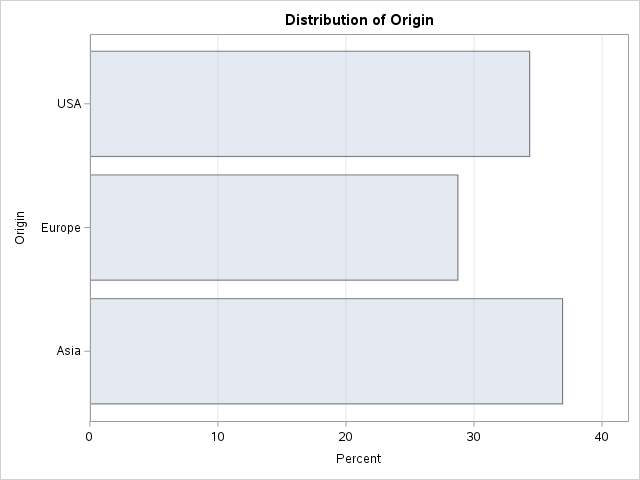

## Two-way frequency table

Use `*` between two columns to count every **combination** of their values.

```
proc freq data=sashelp.cars;
    tables Origin*Type /creates a two-way frequency table
        plots=freqplot(orient=vertical);vertical bar chart. We did not set scale=, so the plot shows counts.
run;
```

We don’t need `ods graphics on` again, since it is still on from the last code.

```sas
/* creating a vertical bar freq plot */
proc freq data=sashelp.cars;
    tables Origin*Type /
        plots=freqplot(orient=vertical);
run;
```

The FREQ Procedure

| Frequency Percent Row Pct Col Pct |
| --- |

| Table of Origin by Type Origin | Table of Origin by Type Type Hybrid | Table of Origin by Type Type SUV | Table of Origin by Type Type Sedan | Table of Origin by Type Type Sports | Table of Origin by Type Type Truck | Table of Origin by Type Type Wagon | Table of Origin by Type Type Total |
| --- | --- | --- | --- | --- | --- | --- | --- |
| Asia | 3 0.70 1.90 100.00 | 25 5.84 15.82 41.67 | 94 21.96 59.49 35.88 | 17 3.97 10.76 34.69 | 8 1.87 5.06 33.33 | 11 2.57 6.96 36.67 | 158 36.92 |
| Europe | 0 0.00 0.00 0.00 | 10 2.34 8.13 16.67 | 78 18.22 63.41 29.77 | 23 5.37 18.70 46.94 | 0 0.00 0.00 0.00 | 12 2.80 9.76 40.00 | 123 28.74 |
| USA | 0 0.00 0.00 0.00 | 25 5.84 17.01 41.67 | 90 21.03 61.22 34.35 | 9 2.10 6.12 18.37 | 16 3.74 10.88 66.67 | 7 1.64 4.76 23.33 | 147 34.35 |
| Total | 3 0.70 | 60 14.02 | 262 61.21 | 49 11.45 | 24 5.61 | 30 7.01 | 428 100.00 |

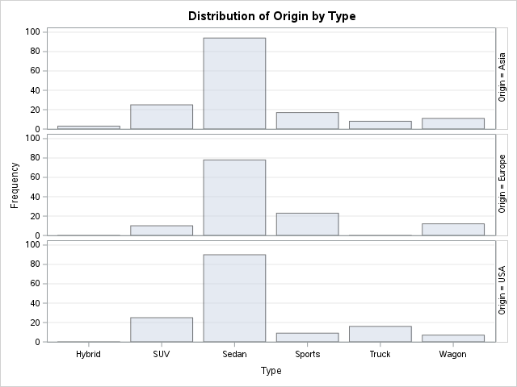

## Stacked bar chart

`twoway=stacked` puts the bars for each `Origin` on top of each other.

```
title1 'Origin of Cars by Type';TITLE and FOOTNOTE add text to the whole report, not just the table or plot.
title2 'Sedan, SUV, Truck';
footnote 'Other types not included: Hybrid, Sports, Wagon';
proc freq data=sashelp.cars;
    tables Origin*Type /
        plots=freqplot(twoway=stacked orient=horizontal);
    where Type in ("Sedan", "SUV", "Truck");
run;
title; footnote;Titles stay on until we clear them. This clears them.
```

```sas
/* creating a stacked bar */
title1 'Origin of Cars by Type';
title2 'Sedan, SUV, Truck';
footnote 'Other types not included: Hybrid, Sports, Wagon';

proc freq data=sashelp.cars;
    tables Origin*Type /
        plots=freqplot(twoway=stacked orient=horizontal);
    where Type in ("Sedan", "SUV", "Truck");
run;

title;
footnote;
```

The FREQ Procedure

| Frequency Percent Row Pct Col Pct |
| --- |

| Table of Origin by Type Origin | Table of Origin by Type Type SUV | Table of Origin by Type Type Sedan | Table of Origin by Type Type Truck | Table of Origin by Type Type Total |
| --- | --- | --- | --- | --- |
| Asia | 25 7.23 19.69 41.67 | 94 27.17 74.02 35.88 | 8 2.31 6.30 33.33 | 127 36.71 |
| Europe | 10 2.89 11.36 16.67 | 78 22.54 88.64 29.77 | 0 0.00 0.00 0.00 | 88 25.43 |
| USA | 25 7.23 19.08 41.67 | 90 26.01 68.70 34.35 | 16 4.62 12.21 66.67 | 131 37.86 |
| Total | 60 17.34 | 262 75.72 | 24 6.94 | 346 100.00 |

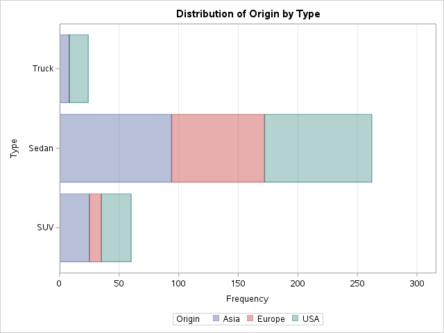

## Exercise

1. Using `ma505.ow_cat` from the last exercise, create a **clustered** vertical bar chart of each player’s `Category`.
   1. Set it up like the stacked bar chart, but change `stacked` to `cluster`.
2. What do the 4 values in each cell of the frequency table mean?

```sas
libname ma505 "~";    /* skip if your autoexec does this */

proc freq data=ma505.ow_cat;
    tables Player*Category /
        plots=freqplot(orient=vertical twoway=cluster);
run;
```

The FREQ Procedure

| Frequency Percent Row Pct Col Pct |
| --- |

| Table of Player by Category Player | Table of Player by Category Category DAMAGE | Table of Player by Category Category HEALS | Table of Player by Category Category Total |
| --- | --- | --- | --- |
| player1 | 48 55.17 85.71 88.89 | 8 9.20 14.29 24.24 | 56 64.37 |
| player2 | 6 6.90 19.35 11.11 | 25 28.74 80.65 75.76 | 31 35.63 |
| Total | 54 62.07 | 33 37.93 | 87 100.00 |

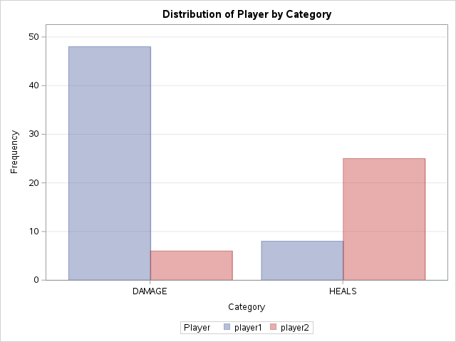

Each cell of a two-way table has 4 values, in this order:

- **Frequency**: the number of games for that player and category.
- **Percent**: that count out of **all** games.
- **Row Pct**: out of that **player’s** games (each row adds to 100).
- **Col Pct**: out of that **category’s** games (each column adds to 100).

## `PROC SGPLOT`

`PROC SGPLOT` makes many kinds of statistical graphics: scatter plots, bar charts, line plots, histograms, box plots, and more. It is part of SAS ODS Graphics.

Compared to the plots in `PROC FREQ`, it gives us:

- **more flexibility** over how the plot looks
- **layering**: more than one plot on the same axes

## `PROC SGPLOT` syntax

```
proc sgplot data=input-table <options>;
    plot statement(s) / <options>;what plot to add (one plot or layered plots), and options for that plot
    <appearance statements>;legend, appearance, axes, symbols
    <additional filtering/formatting/etc.>;any extra data processing, like WHERE or FORMAT
run;
```

## Plot statements

#### Basic

BAND, BUBBLE, BLOCK, DROPLINE, ELLIPSEPARM, FRINGE, HBARPARM, HEATMAP, HEATMAPPARM, HIGHLOW, LINEPARM, NEEDLE, POLYGON, REFLINE, SCATTER, SERIES, SPLINE, STEP, TEXT, VBARPARM, VECTOR

#### Distribution

DENSITY, HBOX, HISTOGRAM, VBOX

#### Fit and Confidence

ELLIPSE, LOESS, PBSPLINE, REG

#### Categorization

DOT, HBAR, HBARBASIC, HLINE, VBAR, VBARBASIC, VLINE, WATERFALL

Only certain groups can be **layered** together: Basic with Fit and Confidence, Distribution with Distribution, and Categorization with Categorization.

- `HBARPARM` assumes the data is **already summarized** (one row per bar).
- `HBAR` assumes the data is **not summarized** (many rows per bar). SAS does the counting or adding for us.

## Summarized vs unsummarized data

**Unsummarized**: one row per game, so each map shows up more than once.

| Map | Damage |
| --- | --- |
| Busan | 3000 |
| Busan | 5000 |
| Busan | 2000 |
| Oasis | 4000 |
| Oasis | 1000 |
| Nepal | 7000 |

Use **`HBAR`**. SAS adds up the rows for each map.

**Summarized**: one row per map. The adding is already done.

| Map | Total_Damage |
| --- | --- |
| Busan | 10000 |
| Oasis | 5000 |
| Nepal | 7000 |

Use **`HBARPARM`**. SAS draws each row as one bar.

## Using the right statement

`HBAR` on the unsummarized table and `HBARPARM` on the summarized table give us the **same** bars. Busan has the most damage. The order is different because `HBAR` sorts the maps A to Z, and `HBARPARM` keeps the order of the rows.

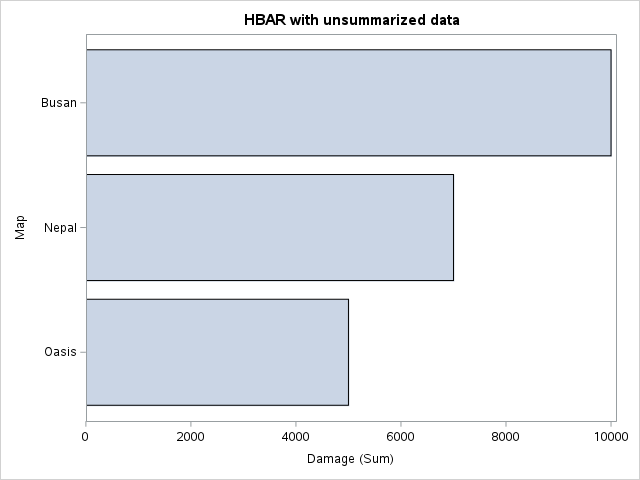

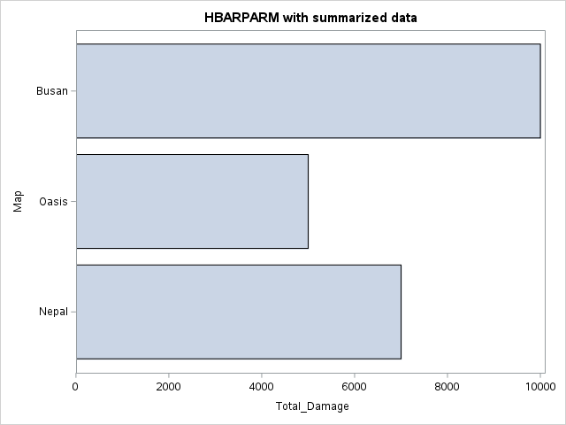

```sas
/* unsummarized data: HBAR adds up the games */
title 'HBAR with unsummarized data';
proc sgplot data=games;
    hbar Map / response=Damage;
run;

/* summarized data: HBARPARM draws one bar per row */
title 'HBARPARM with summarized data';
proc sgplot data=games_sum;
    hbarparm category=Map response=Total_Damage;
run;
title;
```

## Using the wrong statement

What if we switch them?

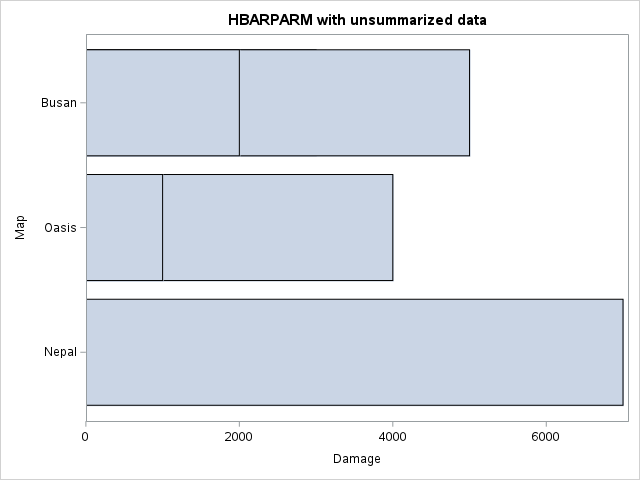

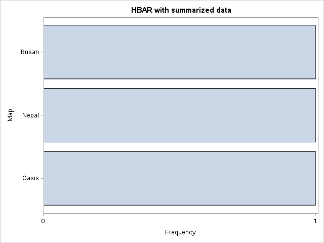

```sas
/* HBARPARM on unsummarized data */
title 'HBARPARM with unsummarized data';
proc sgplot data=games;
    hbarparm category=Map response=Damage;
run;

/* HBAR on summarized data, with no response= */
title 'HBAR with summarized data';
proc sgplot data=games_sum;
    hbar Map;
run;
title;
```

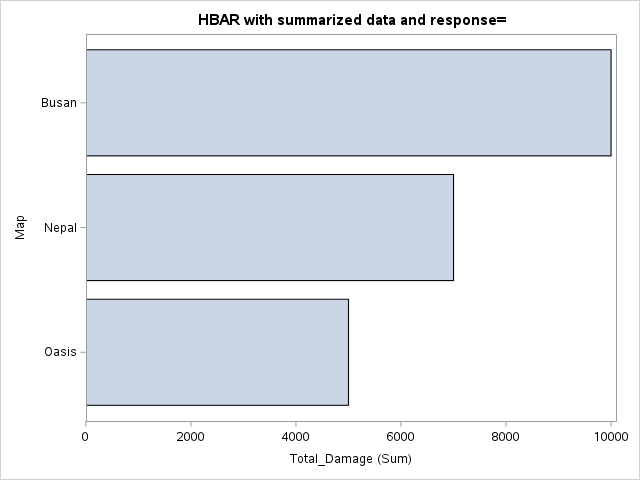

```sas
/* HBAR on summarized data, with response= */
title 'HBAR with summarized data and response=';
proc sgplot data=games_sum;
    hbar Map / response=Total_Damage;
run;
title;
```

- **`HBARPARM` on unsummarized data:** SAS draws one bar for **each game**, all on top of each other. We only see the longest one, so Busan shows 5000 instead of 10000, and now Nepal looks like it has the most damage.
- **`HBAR` on summarized data with no `response=`:** SAS counts the rows. Each map has one row, so every bar is 1.
- **`HBAR` on summarized data with `response=`:** this works! `HBAR` adds up the rows for each map, and adding up one row gives the same number. So `HBAR` works on either kind of data as long as we give it `response=`, but `HBARPARM` only works on summarized data.

Before we plot, look at the data. Is there one row per bar, or many?

## `PROC SGPLOT`: a simple bar chart

With only a category column, `HBAR` counts the rows for each value.

```sas
libname ma505 "~";    /* skip if your autoexec does this */

proc sgplot data=ma505.ow_stats;
    hbar Map;
run;
```

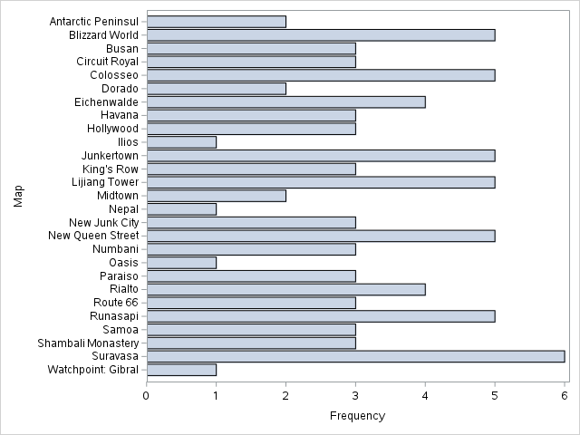

## Adding a response variable

`response=` tells SAS what to measure for each bar. By default it **adds up** (sums) the response.

```sas
proc sgplot data=ma505.ow_stats;
    hbar Map / response=Damage;
run;
```

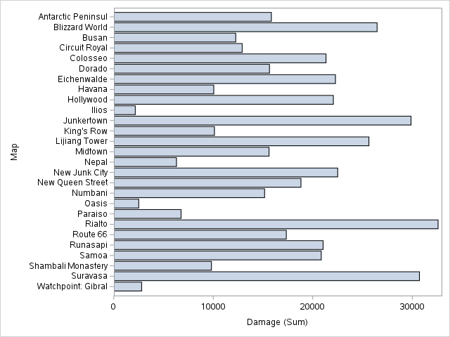

## Choosing the statistic

`stat=` changes how the response is summarized, like `stat=mean` for the average.

```sas
proc sgplot data=ma505.ow_stats;
    hbar Map / response=Damage stat=mean;
run;
```

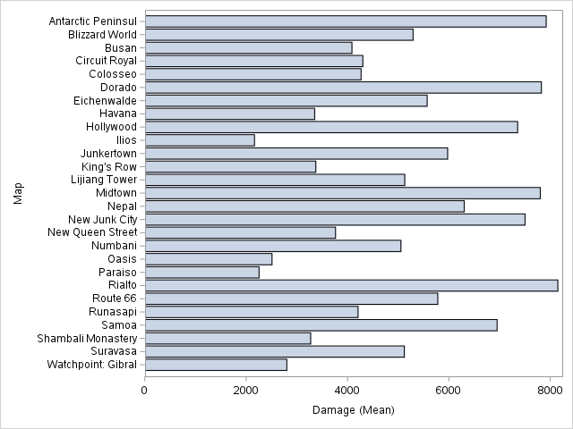

## Exercise

1. Using `ma505.ow_stats`, make a bar chart of the **sum of `Damage` by `Date`** two ways: with `VBAR` and with `VBARPARM`. Compare the outputs.
   1. Are the results what you expected? Why or why not?

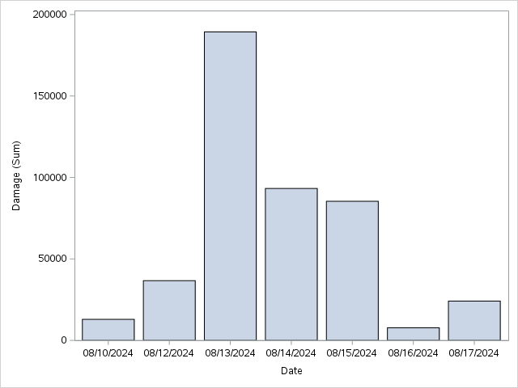

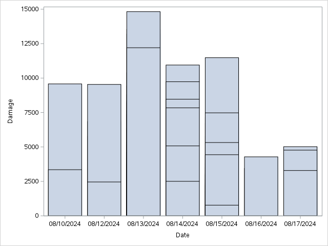

```sas
libname ma505 "~";    /* skip if your autoexec does this */

/* VBAR: SAS adds up Damage for each date */
proc sgplot data=ma505.ow_stats;
    vbar Date / response=Damage stat=sum;
run;

/* VBARPARM: expects one row per date, so it does not add anything up */
proc sgplot data=ma505.ow_stats;
    vbarparm category=Date response=Damage;
run;
```

`VBAR` gives the sum of `Damage` for each date. `VBARPARM` does not. It is a **Basic** plot that expects the data to be summarized already, with one row per bar. Our table has several games on each date, so the bars are drawn on top of each other and do not show the total. To use `VBARPARM` here, we would need to summarize the data first.